# iLipidome

Wen-Jen Lin

7/10/2023

This tutorial presents a series of iLipidome functions that facilitate a comprehensive comparison of lipid profiles using a novel substructure-based approach. iLipidome is an innovative method that leverages the lipid biosynthetic network to analyze lipidomics data, taking into account the interdependence and interconnectedness of measured lipids. It provides ‘Lipid Substructure Analysis’ functionality, allowing users to decompose lipids into substructures, convert lipid expression into substructure expression, reconstruct the lipid biosynthetic network, and identify significant altered lipid pathways and their genetic origins. iLipidome currently supports “two-group comparison” and performs substructure analysis based on fatty acids, lipid species, or lipid classes, enabling comprehensive comparisons of lipid profiles across different levels. Our goal is to empower researchers with a deeper understanding of the intricate changes in lipidomics observed across various samples.

## Library iLipidome package

```r
library("iLipidome")
```

## Upload lipidomics data

iLipidome only requires users to upload a processed lipid expression table (data.frame) for analysis. The table should have lipids as rows and samples as columns. Lipid names should be placed in the first column, labeled as “feature”, and sample names should be in the first row. It is important to have a minimum of two samples in each group for accurate statistical calculations. Depending on the data source, preprocessing and normalization techniques like missing value imputation or log transformation may be necessary to improve analysis outcomes.

Lipid names in the table can be represented in two formats:  
1. When the exact identity of FAs is unknown, the lipids can be represented using the following format:  
[LipidClassAbbreviation]_[sum of FA chain length] : [sum of FA double bonds] ; [sum of FA oxygens]  
For example, PC_34:1;0 or TAG_52:1;0  
2. When the exact identity of FAs is known, the lipids can be represented using the following format:  
[LipidClassAbbreviation]_[FA1 chain length] : [FA1 double bonds] ; [FA1 oxygens]_[FA2 chain length] : [FA2 double bonds] ; [FA2 oxygens]…  
For example, PC_16:0;0_18:1;0 or TAG_16:0;0_18:0;0_18:1;0

You can refer to the ‘supported_lipid_class.csv’ file for the supported lipid classes, their abbreviations, and the corresponding number of FAs. Note that when using the exact identity format of FAs, we will verify if the fatty acid numbers match those recorded in the ‘supported_lipid_class.csv’ file. If they do not match, the analysis will be interrupted. Also, lipid classes with the same number of FAs (e.g., PC, PE) in the same pathways (e.g., Glycerophospholipid) should have a consistent lipid naming format. For example, PC_36:0;0 and PE_34:0;0 or PC_18:0;0_18:0;0 and PE_16:0;0_18:0;0. Additionally, dihydrosphingolipids (dh-) specify sphingolipids with sphingoid bases of 18:0:2 instead of 18:1:2.

```r
#Expression table of example lipidomics dataset
head(example_dataset_FA)
```

```
##     feature Ctrl1 Ctrl2      Ctrl3      Ctrl4      Ctrl5      Ctrl6      Ctrl7
## 1 CL_68:2;0     0     0 0.00000000 0.04866205 0.06397223 0.04436463 0.03899249
## 2 CL_68:4;0     0     0 0.09463676 0.06303304 0.02377526 0.06901526 0.11229305
## 3 CL_68:5;0     0     0 0.06566191 0.03487172 0.02243281 0.00000000 0.03032653
## 4 CL_70:0;0     0     0 0.00000000 0.09747633 0.02949352 0.11806781 0.07542087
## 5 CL_70:4;0     0     0 0.03881750 0.06291613 0.05488776 0.10379507 0.10311343
## 6 CL_70:5;0     0     0 0.10081207 0.11377321 0.07182146 0.11630410 0.10872304
##   DHA1       DHA2       DHA3       DHA4       DHA5 DHA6
## 1    0 0.00000000 0.00000000 0.04048669 0.03433683    0
## 2    0 0.08089873 0.04413522 0.03147433 0.09176335    0
## 3    0 0.06891725 0.04235986 0.02352101 0.02595432    0
## 4    0 0.00000000 0.00000000 0.05878676 0.08465444    0
## 5    0 0.00000000 0.02807038 0.04583594 0.09512298    0
## 6    0 0.06638275 0.09763119 0.10339660 0.09995456    0
```

## 1. FA substructure analysis

### 1-1. Run analysis

The FA_substructure_analysis function allows users to conduct fatty acid substructure analysis and generates visualizations in the form of tables, bar plots, and networks. These visualizations assist in understanding and interpreting the results of the analysis. The parameters are listed below:

1. exp_raw: The input should be a data frame with lipid species as rows and samples as columns. The first column should contain lipid names, and the remaining columns should consist of numeric lipid values.
2. method: A character string specifying the statistical method to be used. The available options are two-sample t-tests (“t.test”) or Wilcoxon tests (“wilcox.test”).
3. ctrl: An integer vector specifying the samples in the control group within the lipid expression table. The first column, which contains lipid names, is not included in the count.
4. exp: An integer vector specifying the samples in the experimental group within the lipid expression table.
5. unmapped_FA: NULL or a character vector that allows users to specify which fatty acids (FAs) should be ignored. Users can refer to the “S1” and “P1” columns of “FA_network” to identify and select specific fatty acid names. Due to limitations in mass spectrometry, precise double bond locations for fatty acids are often not available in lipidomics data. As a result, certain fatty acids may have multiple candidate mappings in the fatty acid network. However, some fatty acid isomers may be dominant, while others may be negligible. For exmaple, the major isomer of FA 20:4 is omega-6, not omega-3. Treating all isomers equally in the substructure calculation may not accurately reflect their true abundance. This parameter enables users to select low-expressed fatty acid isomers to exclude from decomposition into substructures within the fatty acid network, therefore improving the accuracy of calculations.
6. exo_lipid: NULL or character vector used to specify the exogenous lipid treatment in the analysis. If an exogenous lipid treatment is involved in the study, it can significantly influence the results of substructure calculation based on biosynthetic pathways. To address this issue, iLipidome provides a parameter for users to exclude the effects of the exogenous treatment. Users can refer to the “S1” and “P1” columns of “FA_network” to identify and select specific fatty acid names.
7. species: “human”, “mouse”, or “rat” can be used to label species-specific genes for lipid reactions.
8. add_reaction: NULL or a data frame consisting of three columns: “from”, “to”, and “pathway” to add the fatty acid reactions. The fatty acids in the “from” and “to” columns should adhere to the format [FA chain length]:[FA double bonds];[FA oxygens]. The prefixes “w9-”, “w7-”, “w6-”, and “w3-” can also be included to provide information about the double bond position. The “pathway” column in the table can take one of the following values: “Non_essential_FA_synthesis”, “Omega_6_FA_synthesis”, “Omega_3_FA_synthesis”, or “Unknown”.
9. delete_reaction: NULL or a data frame consisting of two columns: “from” and “to” delete the fatty acid reactions. The fatty acids in the “from” and “to” columns should correspond to the fatty acids listed in the “S1” and “P1” columns of “FA_network”.

Users can fine-tune these parameters to achieve optimal results.

```r
FA_substructure_result <-
  FA_substructure_analysis(exp_raw = example_dataset_FA,
                           method='t.test',
                           ctrl=1:7, exp=8:13,
                           unmapped_FA = c('w9-18:2;0','w3-20:4;0'),
                           exo_lipid='w3-22:6;0', species='rat',
                           add_reaction = NULL,
                           delete_reaction = NULL)
```

```
## [1] "Substructure transformation complete."
## [1] "Pathway analysis complete."
## [1] "Reaction analysis complete."
## [1] "Network analysis complete."
```

### 1-2. Differential expression analysis

In this section, we present the results of the differential expression analysis conducted on the substructure-transformed data.

```r
#Differential expression result table
head(FA_substructure_result[[1]])
```

```
##   Substructure Mean(ctrl) Mean(exp)         FC   Log2(FC)       P-value
## 1    w9-20:2;0  7.5023315  3.298843  0.4397090 -1.1853790 0.00014554712
## 2    w9-20:1;0  5.7569368  2.368271  0.4113769 -1.2814673 0.00013607164
## 3    w9-18:2;0  3.7511657  1.649421  0.4397090 -1.1853790 0.00014554712
## 4    w9-18:1;0 45.6102465 33.105496  0.7258346 -0.4622872 0.00013619984
## 5    w3-22:6;0  0.2687787 14.306305 53.2270832  5.7340886 0.00003061004
## 6  exo: 14:0;0 30.1543324 37.427886  1.2412109  0.3117483 0.00018589656
##   Adjusted p-value Significance
## 1     0.0007942853          yes
## 2     0.0007942853          yes
## 3     0.0007942853          yes
## 4     0.0007942853          yes
## 5     0.0007942853          yes
## 6     0.0007942853          yes
```

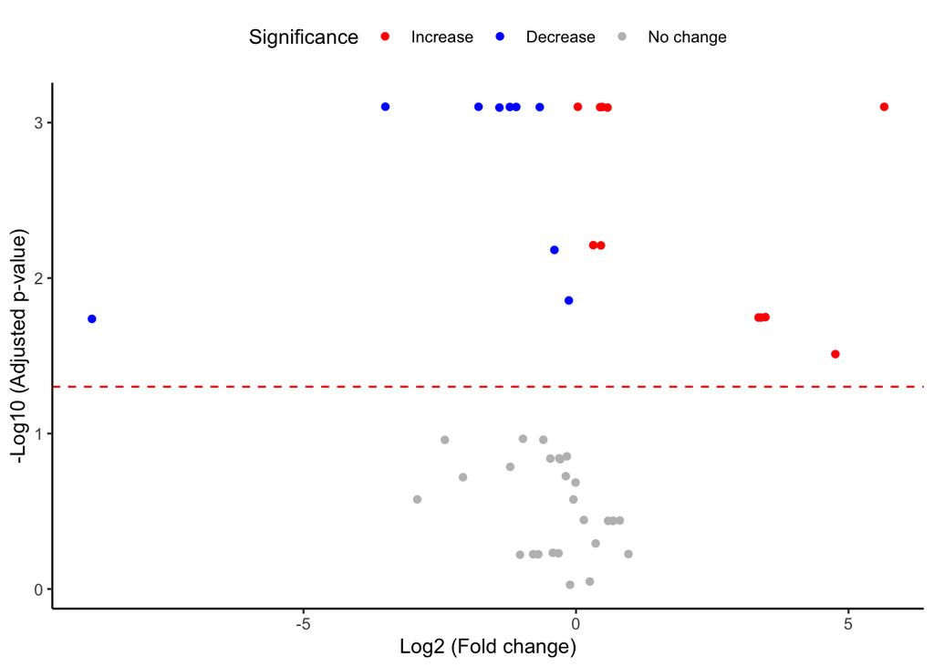

```r
#Volcano plot of differentially expressed substructures
FA_substructure_result[[2]]
```

### 1-3. Pathway analysis results

In the ‘Pathway analysis’ section, the figure showcases the top 5 significant representative pathways within the network. Increased pathways are highlighted in red, while decreased pathways are shown in blue. A pathway is considered significant if its score exceeds 1.96. The figure represents pathways using starting and ending lipids. Additionally, a comprehensive summary of all significant pathways can be found in the accompanying table. For a deeper understanding of how we calculate pathway scores, calibrate pathways, and select representative pathways, detailed information is available in the iLipidome paper.

```r
#Pathway analysis result table
head(FA_substructure_result[[3]])
```

```
##                                                                                         Pathway
## 1                              endo: 2:0;0--10:0;0 --> endo: 12:0;0 --> endo: 14:0;0 --> 16:0;0
## 2                   endo: 2:0;0--10:0;0 --> endo: 12:0;0 --> endo: 14:0;0 --> 16:0;0 --> 18:0;0
## 3               w3-18:4;0 --> w3-20:4;0 --> w3-20:5;0 --> w3-22:5;0 --> w3-22:6;0 --> w3-24:6;0
## 4 w3-18:3;0 --> w3-18:4;0 --> w3-20:4;0 --> w3-20:5;0 --> w3-22:5;0 --> w3-22:6;0 --> w3-24:6;0
## 5        endo: 2:0;0--10:0;0 --> endo: 12:0;0 --> endo: 14:0;0 --> 16:0;0 --> 18:0;0 --> 20:0;0
## 6                                         endo: 2:0;0--10:0;0 --> endo: 12:0;0 --> endo: 14:0;0
##                  From           To    Score Significant   Type
## 1 endo: 2:0;0--10:0;0       16:0;0 3.248677         yes Active
## 2 endo: 2:0;0--10:0;0       18:0;0 3.223859         yes Active
## 3           w3-18:4;0    w3-24:6;0 3.013711         yes Active
## 4           w3-18:3;0    w3-24:6;0 2.932832         yes Active
## 5 endo: 2:0;0--10:0;0       20:0;0 2.873106         yes Active
## 6 endo: 2:0;0--10:0;0 endo: 14:0;0 2.856341         yes Active
##                                                            Representative pathway
## 1                endo: 2:0;0--10:0;0 --> endo: 12:0;0 --> endo: 14:0;0 --> 16:0;0
## 2                endo: 2:0;0--10:0;0 --> endo: 12:0;0 --> endo: 14:0;0 --> 16:0;0
## 3 w3-18:4;0 --> w3-20:4;0 --> w3-20:5;0 --> w3-22:5;0 --> w3-22:6;0 --> w3-24:6;0
## 4 w3-18:4;0 --> w3-20:4;0 --> w3-20:5;0 --> w3-22:5;0 --> w3-22:6;0 --> w3-24:6;0
## 5                endo: 2:0;0--10:0;0 --> endo: 12:0;0 --> endo: 14:0;0 --> 16:0;0
## 6                endo: 2:0;0--10:0;0 --> endo: 12:0;0 --> endo: 14:0;0 --> 16:0;0
```

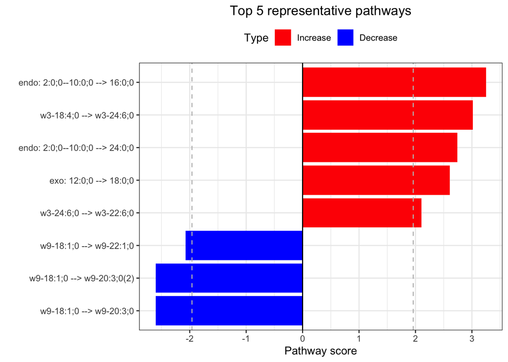

```r
#Top 5 significant representative pathways
FA_substructure_result[[4]]
```

### 1-4. Reaction analysis results

In the ‘Reaction analysis’ section, the figure showcases the top 5 significant reactions within the network, where red and blue colors indicate an increase and decrease, respectively. A reaction is deemed significant if its p-value is below 0.05. These reactions are represented by substrate and product lipids, with red and blue text denoting the fold change of lipids. A comprehensive summary of all significant reactions is provided in the accompanying table. For a more detailed understanding of how we calculate reaction scores, please refer to the information in the iLipidome paper.

```r
#Reaction analysis result table
head(FA_substructure_result[[5]])
```

```
##                  Reaction     P-value Perturbation score Significant     Type
## 1 w3-22:5;0 --> w3-22:6;0 0.006164558          12.881324         yes Increase
## 2 w3-18:3;0 --> w3-18:4;0 0.102386321           5.272706          no Increase
## 3 w3-24:6;0 --> w3-22:6;0 0.062269879           5.146661          no Increase
## 4 w9-22:1;0 --> w9-24:1;0 0.020923038           1.541346         yes Increase
## 5 w9-20:2;0 --> w9-20:3;0 0.006973126           1.324553         yes Increase
## 6 w6-22:4;0 --> w6-24:4;0 0.176452643           1.295596          no Increase
##                                                  Gene
## 1                                               Fads2
## 2                                               Fads2
## 3         Acaa1a, Acaa1b, Acox1, Acox3, Hsd17b4, Scp2
## 4 Elovl1, Elovl3, Hacd1, Hacd3, Hacd4, Hsd17b12, Tecr
## 5                                               Fads1
## 6         Elovl2, Hacd1, Hacd3, Hacd4, Hsd17b12, Tecr
```

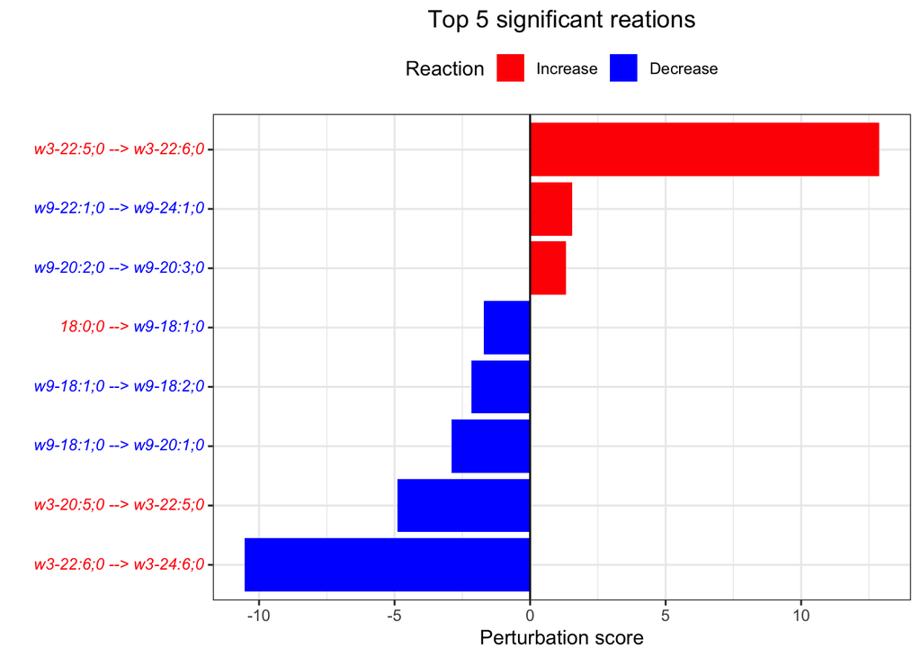

```r
#Top 5 significant reactions
FA_substructure_result[[6]]
```

### 1-5. Lipid network

In the ‘Lipid network’ section, we constructed the Fatty Acid Network and highlighted the top 5 significantly increased/decreased representative pathways and reactions. In the network visualization, red and blue colors indicate increase and decrease, respectively. The line width and color depth reflect the importance of pathways, while the text size represents the significance of reactions. Additionally, the nodes in the figure are filled based on the log2(fold change) values, and their sizes represent −log10(adjusted p-value). If a node exhibits significant changes in abundance, its border will be highlighted in purple. It’s important to note that for the Lipid Species Network, we only include the significant pathways that belong to the top 5 increased and decreased representative pathways to simplify the connections and enhance the clarity of the network visualization.

```r
#Node information for the network
head(FA_substructure_result[[7]])
```

```
##       id  label color.background color.border borderWidth     value font.size
## 1 16:0;0 16:0;0          #FFF5F5       purple         2.5 2.2083031        35
## 2 18:0;0 18:0;0          #FFF5F5        black         1.0 0.5785417        35
## 3 20:0;0 20:0;0          #EAEAFF        black         1.0 0.2321306        35
## 4 22:0;0 22:0;0          #EAEAFF        black         1.0 0.2233110        35
## 5 24:0;0 24:0;0          #FFE0E0        black         1.0 0.4409234        35
## 6 26:0;0 26:0;0            black  transparent         0.0 0.0000000        35
##    Mean(ctrl)   Mean(exp)        FC   Log2(FC)     P-value Adjusted p-value
## 1 54.78231471 68.16449965 1.2442793  0.3153103 0.001712152       0.00619009
## 2 19.81315681 23.26637669 1.1742892  0.2317878 0.185299571       0.26391151
## 3  0.08969239  0.06184592 0.6895337 -0.5363071 0.511158298       0.58596195
## 4  0.06433713  0.04475463 0.6956269 -0.5236144 0.549271351       0.59798323
## 5  0.03692008  0.06536674 1.7704929  0.8241511 0.285396233       0.36230693
## 6          NA          NA        NA         NA          NA               NA
##   Significance
## 1          yes
## 2           no
## 3           no
## 4           no
## 5           no
## 6         <NA>
```

```r
#Edge information for the network
head(FA_substructure_result[[8]])
```

```
##        from        to   color arrows length width    label font.size font.color
## 1 w9-20:2;0 w9-20:3;0 #0000FF     to    100    12 Increase      35.0        red
## 2 w9-22:1;0 w9-24:1;0   black     to    100     1 Increase      42.5        red
## 3 w6-20:3;0 w6-20:4;0   black     to    100     1 Increase      27.5        red
## 4 w3-22:5;0 w3-22:6;0 #FF3939     to    100    10 Increase      50.0        red
## 5    18:0;0 w9-18:1;0   black     to    100     1 Decrease      20.0       blue
## 6 w9-18:1;0 w9-18:2;0 #3939FF     to    100    10 Decrease      27.5       blue
##                  Reaction     P-value Perturbation score     Type
## 1 w9-20:2;0 --> w9-20:3;0 0.006973126          1.3245530 Increase
## 2 w9-22:1;0 --> w9-24:1;0 0.020923038          1.5413463 Increase
## 3 w6-20:3;0 --> w6-20:4;0 0.040375748          0.8542681 Increase
## 4 w3-22:5;0 --> w3-22:6;0 0.006164558         12.8813238 Increase
## 5    18:0;0 --> w9-18:1;0 0.006718734         -1.7082326 Decrease
## 6 w9-18:1;0 --> w9-18:2;0 0.001009861         -2.1758483 Decrease
##                                                  Gene
## 1                                               Fads1
## 2 Elovl1, Elovl3, Hacd1, Hacd3, Hacd4, Hsd17b12, Tecr
## 3                                               Fads1
## 4                                               Fads2
## 5                               Scd, Scd2, Scd3, Scd4
## 6                                               Fads2
```

```r
#Lipid network
FA_substructure_result[[9]]
```

[interactive chart not shown]

### 1-6. Modify lipid network

“add_reaction” and “delete_reaction” parameters allow users to add or delete the reactions in the network

```r
add_reaction <- data.frame(from=c("15:0;0","17:0;0","19:0;0"),
                           to=c("17:0;0","19:0;0","21:0;0"),
                           pathway='unknown')
delete_reaction <- data.frame(from='w9-20:1;0', to='w9-20:2;0')

FA_substructure_result <-
  FA_substructure_analysis(example_dataset_FA, method='t.test',
                           ctrl=1:7, exp=8:13,
                           unmapped_FA = c('w9-18:2;0','w3-20:4;0'),
                           exo_lipid='w3-22:6;0', species='rat',
                           add_reaction = add_reaction,
                           delete_reaction = delete_reaction)
```

```
## [1] "Substructure transformation complete."
## [1] "Pathway analysis complete."
## [1] "Reaction analysis complete."
## [1] "Network analysis complete."
```

```r
#Modified lipid network
FA_substructure_result[[9]]
```

[interactive chart not shown]

## 2. Lipid class substructure analysis

### 2-1. Run analysis

The lipid_class_substructure_analysis function allows users to conduct lipid class substructure analysis and generates visualizations in the form of tables, bar plots, and networks. These visualizations assist in understanding and interpreting the results of the analysis. The parameters are listed below:

1. exp_raw: The input should be a data frame with lipid species as rows and samples as columns. The first column should contain lipid names, and the remaining columns should consist of numeric lipid values.
2. method: A character string specifying the statistical method to be used. The available options are two-sample t-tests (“t.test”) or Wilcoxon tests (“wilcox.test”).
3. ctrl: An integer vector specifying the samples in the control group within the lipid expression table. The first column, which contains lipid names, is not included in the count.
4. exp: An integer vector specifying the samples in the experimental group within the lipid expression table.
5. exo_lipid: NULL or character vector used to specify the exogenous lipid treatment in the analysis. If an exogenous lipid treatment is involved in the study, it can significantly influence the results of substructure calculation based on biosynthetic pathways. To address this issue, iLipidome provides a parameter for users to exclude the effects of the exogenous treatment. Users can refer to the “Abbreviation” column of “network_node” to identify and select specific lipid class names.
6. species: “human”, “mouse”, or “rat” can be used to label species-specific genes for lipid reactions.
7. add_reaction: NULL or a data frame consisting of three columns: “from” and “to” add the lipid reactions. The lipids in the “from” and “to” columns should be included in the “Abbreviation” column of “network_node”.
8. delete_reaction: NULL or a data frame consisting of three columns: “from” and “to” delete the lipid reactions. The lipids in the “from” and “to” columns should be included in the “Abbreviation” column of “network_node”.

Users can fine-tune these parameters to achieve optimal results.

```r
lipid_class_substructure_result <-
  lipid_class_substructure_analysis(example_dataset_LipidClass, method='t.test',
                                    ctrl=1:7, exp=8:13,
                                    exo_lipid=NULL, species='rat',
                                    add_reaction = NULL,
                                    delete_reaction =NULL)
```

```
## [1] "Substructure transformation complete."
## [1] "Pathway analysis complete."
## [1] "Reaction analysis complete."
## [1] "Network analysis complete."
```

### 2-2. Differential expression results

In this section, we present the results of the differential expression analysis conducted on the substructure-transformed data.

```r
#Differential expression result table
head(lipid_class_substructure_result[[1]])
```

```
##   Substructure Mean(ctrl) Mean(exp)        FC   Log2(FC)   P-value
## 1           PS  19.378963 17.210955 0.8881257 -0.1711642 0.1819557
## 2           PE  19.378963 17.210955 0.8881257 -0.1711642 0.1819557
## 3        PC O-   8.139272  5.294944 0.6505426 -0.6202845 0.1237683
## 4           PC  53.545106 58.932913 1.1006218  0.1383188 0.2323097
## 5        PA O-  18.753540 15.740614 0.8393410 -0.2526711 0.1616950
## 6       LPA O-  18.753540 15.740614 0.8393410 -0.2526711 0.1616950
##   Adjusted p-value Significance
## 1        0.4688655           no
## 2        0.4688655           no
## 3        0.4688655           no
## 4        0.4688655           no
## 5        0.4688655           no
## 6        0.4688655           no
```

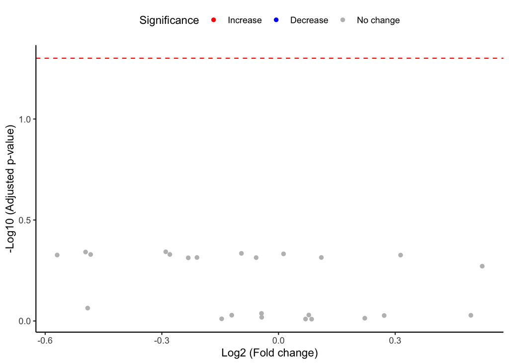

```r
#Volcano plot of differentially expressed substructures
lipid_class_substructure_result[[2]]
```

### 2-3. Pathway analysis results

In the ‘Pathway analysis’ section, the figure showcases the top 5 significant representative pathways within the network. Increased pathways are highlighted in red, while decreased pathways are shown in blue. A pathway is considered significant if its score exceeds 1.96. The figure represents pathways using starting and ending lipids. Additionally, a comprehensive summary of all significant pathways can be found in the accompanying table. For a deeper understanding of how we calculate pathway scores, calibrate pathways, and select representative pathways, detailed information is available in the iLipidome paper.

```r
#Pathway analysis result table
head(lipid_class_substructure_result[[3]])
```

```
##                                                   Pathway From To    Score
## 1 LPI --> PI --> DAG --> PC --> LPC --> LPA --> PA --> PG  LPI PG 3.284962
## 2                                       DAG --> PC --> PG  DAG PG 3.181615
## 3         LPC --> LPA --> PA --> PI --> DAG --> PC --> PG  LPC PG 3.168984
## 4         PI --> DAG --> PC --> LPC --> LPA --> PA --> PG   PI PG 3.168984
## 5                DAG --> PC --> LPC --> LPA --> PA --> PG  DAG PG 3.158229
## 6                LPC --> LPA --> PA --> DAG --> PC --> PG  LPC PG 3.158229
##   Significant   Type                                  Representative pathway
## 1         yes Active LPI --> PI --> DAG --> PC --> LPC --> LPA --> PA --> PG
## 2         yes Active LPI --> PI --> DAG --> PC --> LPC --> LPA --> PA --> PG
## 3         yes Active LPI --> PI --> DAG --> PC --> LPC --> LPA --> PA --> PG
## 4         yes Active LPI --> PI --> DAG --> PC --> LPC --> LPA --> PA --> PG
## 5         yes Active LPI --> PI --> DAG --> PC --> LPC --> LPA --> PA --> PG
## 6         yes Active LPI --> PI --> DAG --> PC --> LPC --> LPA --> PA --> PG
```

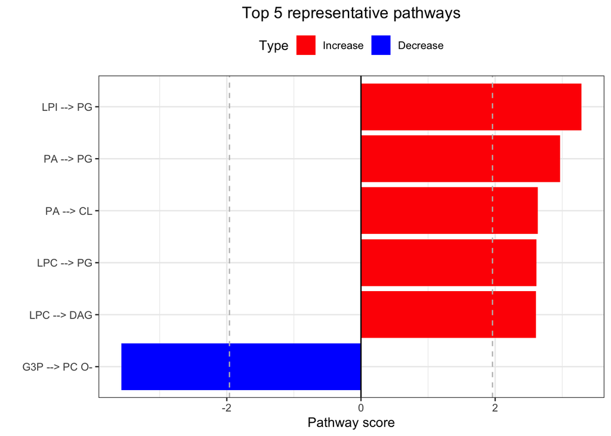

```r
#Top 5 significant representative pathways
lipid_class_substructure_result[[4]]
```

### 2-4. Reaction analysis results

In the ‘Reaction analysis’ section, the figure showcases the top 5 significant reactions within the network, where red and blue colors indicate an increase and decrease, respectively. A reaction is deemed significant if its p-value is below 0.05. These reactions are represented by substrate and product lipids, with red and blue text denoting the fold change of lipids. A comprehensive summary of all significant reactions is provided in the accompanying table. For a more detailed understanding of how we calculate reaction scores, please refer to the information in the iLipidome paper.

```r
#Reaction analysis result table
head(lipid_class_substructure_result[[5]])
```

```
##           Reaction    P-value Perturbation score Significant     Type
## 1        PA --> PG 0.08167096         0.54017019          no Increase
## 2 PC O- --> LPC O- 0.39269737         0.27863410          no Increase
## 3 DAG O- --> PE O- 0.15684944         0.17103050          no Increase
## 4        PE --> PC 0.24206442         0.16849343          no Increase
## 5       PS --> LPS 0.52871144         0.13273542          no Increase
## 6      G3P --> LPA 0.31192415         0.08062927          no Increase
##                                                                                                                                                                   Gene
## 1                                                                                                                                             Cds1, Cds2, Pgs1, Tamm41
## 2 Pla2g10, Pla2g12a, Pla2g12b, Pla2g1b, Pla2g2a, Pla2g2c, Pla2g2d, Pla2g2f, Pla2g3, Pla2g4a, Pla2g4b, Pla2g4c, Pla2g4d, Pla2g4e, Pla2g4f, Pla2g5, Pla2g6, Plaat3, Plb1
## 3                                                                                                                                                       Cept1, Selenoi
## 4                                                                                                                                                                 Pemt
## 5 Pla2g10, Pla2g12a, Pla2g12b, Pla2g1b, Pla2g2a, Pla2g2c, Pla2g2d, Pla2g2f, Pla2g3, Pla2g4a, Pla2g4b, Pla2g4c, Pla2g4d, Pla2g4e, Pla2g4f, Pla2g5, Pla2g6, Plaat3, Plb1
## 6                                                                                                                                            Gpam, Gpat2, Gpat3, Gpat4
```

```r
#Top 5 significant reactions
lipid_class_substructure_result[[6]]
```

```
## [1] NA
```

### 2-5. Lipid network

In the ‘Lipid network’ section, we constructed the Lipid Class Network and highlighted the top 5 significantly increased/decreased representative pathways and reactions. In the network visualization, red and blue colors indicate increase and decrease, respectively. The line width and color depth reflect the importance of pathways, while the text size represents the significance of reactions. Additionally, the nodes in the figure are filled based on the log2(fold change) values, and their sizes represent −log10(adjusted p-value). If a node exhibits significant changes in abundance, its border will be highlighted in purple. It’s important to note that for the Lipid Species Network, we only include the significant pathways that belong to the top 5 increased and decreased representative pathways to simplify the connections and enhance the clarity of the network visualization.

```r
#Node information for the network
head(lipid_class_substructure_result[[7]])
```

```
##    id label color.background color.border borderWidth      value font.size
## 1  PG    PG          #FFB1B1        black           1 0.27403316        35
## 2  PC    PC          #FFE0E0        black           1 0.32895169        35
## 3  PA    PA          #F5F5FF        black           1 0.02485367        35
## 4  PI    PI          #FAFAFF        black           1 0.02485367        35
## 5 LPI   LPI          #FFF5F5        black           1 0.02485367        35
## 6 LPA   LPA          #F5F5FF        black           1 0.02485367        35
##   Mean(ctrl)  Mean(exp)        FC    Log2(FC)   P-value Adjusted p-value
## 1  0.5679506  0.7288396 1.2832799  0.35983582 0.2882033        0.5320676
## 2 53.5451064 58.9329127 1.1006218  0.13831884 0.2323097        0.4688655
## 3  6.3540786  6.1903109 0.9742264 -0.03767107 0.8468811        0.9443790
## 4  6.1729515  6.1173809 0.9909977 -0.01304636 0.9443790        0.9443790
## 5  0.1965971  0.2022748 1.0288797  0.04107436 0.9172148        0.9443790
## 6  6.3540786  6.1903109 0.9742264 -0.03767107 0.8468811        0.9443790
##   Significance
## 1           no
## 2           no
## 3           no
## 4           no
## 5           no
## 6           no
```

```r
#Edge information for the network
head(lipid_class_substructure_result[[8]])
```

```
##   from  to   color arrows length width label font.size font.color   Reaction
## 1   PG  CL #FF7272     to    100     8               0      black  PG --> CL
## 2   PC  PG #FF3939     to    100    10               0      black  PC --> PG
## 3   PA  PI #FF7272     to    100     8               0      black  PA --> PI
## 4   PA  PG #FF0000     to    100    12               0      black  PA --> PG
## 5   PI LPI   black     to    100     1               0      black PI --> LPI
## 6   PI DAG #FF0000     to    100    12               0      black PI --> DAG
##      P-value Perturbation score     Type
## 1 0.06820555        -0.88654983 Decrease
## 2 0.76050539         0.01572498 Increase
## 3 0.33536609         0.01011876 Increase
## 4 0.08167096         0.54017019 Increase
## 5 0.56696187         0.04479437 Increase
## 6 0.53541780         0.05208022 Increase
##                                                                                                                                                                   Gene
## 1                                                                                                                                                                Crls1
## 2                                                                                                                                         Pld1, Pld2, Pld3, Pld4, Pld6
## 3                                                                                                                                            Cdipt, Cds1, Cds2, Tamm41
## 4                                                                                                                                             Cds1, Cds2, Pgs1, Tamm41
## 5 Pla2g10, Pla2g12a, Pla2g12b, Pla2g1b, Pla2g2a, Pla2g2c, Pla2g2d, Pla2g2f, Pla2g3, Pla2g4a, Pla2g4b, Pla2g4c, Pla2g4d, Pla2g4e, Pla2g4f, Pla2g5, Pla2g6, Plaat3, Plb1
## 6                                                                            Plcb1, Plcb2, Plcb3, Plcb4, Plcd1, Plcd3, Plcd4, Plce1, Plcg1, Plcg2, Plch1, Plch2, Plcz1
```

```r
#Lipid network
lipid_class_substructure_result[[9]]
```

[interactive chart not shown]

### 1-6. Modify lipid network

“add_reaction” and “delete_reaction” parameters allow users to add or delete the reactions in the network

```r
add_reaction <- data.frame(from='CL', to='PG')
delete_reaction <- data.frame(from='PE', to='PC')

lipid_class_substructure_result <-
  lipid_class_substructure_analysis(example_dataset_LipidClass, method='t.test',
                                    ctrl=1:7, exp=8:13,
                                    exo_lipid=NULL, species='rat',
                                    add_reaction = add_reaction,
                                    delete_reaction = delete_reaction)
```

```
## [1] "Substructure transformation complete."
## [1] "Pathway analysis complete."
## [1] "Reaction analysis complete."
## [1] "Network analysis complete."
```

```r
#Modified lipid network
lipid_class_substructure_result[[9]]
```

[interactive chart not shown]

## 3. Lipid species substructure analysis

### 3-1. Run analysis

The lipid_species_substructure_analysis function allows users to conduct lipid species substructure analysis and generates visualizations in the form of tables, bar plots, and networks. These visualizations assist in understanding and interpreting the results of the analysis. The parameters are listed below:

1. exp_raw: The input should be a data frame with lipid species as rows and samples as columns. The first column should contain lipid names, and the remaining columns should consist of numeric lipid values.
2. method: A character string specifying the statistical method to be used. The available options are two-sample t-tests (“t.test”) or Wilcoxon tests (“wilcox.test”).
3. ctrl: An integer vector specifying the samples in the control group within the lipid expression table. The first column, which contains lipid names, is not included in the count.
4. exp: An integer vector specifying the samples in the experimental group within the lipid expression table.
5. non_missing_pct: A value between 0 and 1 to set the threshold for the percentage of non-missing values in a biosynthetic pathway. Increasing this value will result in fewer biosynthetic pathways being retained. This parameter enables users to regulate the substructure decomposition process, reducing artifacts that may arise from excessive decomposition. Usually, values between 0.3 and 0.7 are commonly used for this parameter.
6. exo_lipid: NULL or character vector used to specify the exogenous lipid treatment in the analysis. If an exogenous lipid treatment is involved in the study, it can significantly influence the results of substructure calculation based on biosynthetic pathways. To address this issue, iLipidome provides a parameter for users to exclude the effects of the exogenous treatment. Please ensure that the lipid names you enter correspond to those present in the ‘feature’ column of the uploaded dataset.
7. species: “human”, “mouse”, or “rat” can be used to label species-specific genes for lipid reactions.
8. add_reaction: NULL or a data frame consisting of three columns: “from” and “to” add the lipid reactions. The lipids in the “from” and “to” columns should be included in the “Abbreviation” column of “network_node”.
9. delete_reaction: NULL or a data frame consisting of three columns: “from” and “to” delete the lipid reactions. The lipids in the “from” and “to” columns should be included in the “Abbreviation” column of “network_node”.

Users can fine-tune these parameters to achieve optimal results.

```r
lipid_species_substructure_result <-
  lipid_species_substructure_analysis(example_dataset_LipidSpecies,
                                      method='t.test',
                                      ctrl=1:7, exp=8:13,
                                      non_missing_pct = 0.3,
                                      exo_lipid=NULL, species='rat',
                                      add_reaction = NULL,
                                      delete_reaction =NULL)
```

```
## [1] "Substructure transformation complete."
## [1] "Pathway analysis complete."
## [1] "Reaction analysis complete."
## [1] "Network analysis complete."
```

### 3-2. Differential expression results

In this section, we present the results of the differential expression analysis conducted on the substructure-transformed data.

```r
#Differential expression result table
head(lipid_species_substructure_result[[1]])
```

```
##       Substructure  Mean(ctrl)  Mean(exp)          FC  Log2(FC)         P-value
## 1 PG_22:6;0_22:6;0 0.007551899 0.54764756 72.51785715  6.180264 0.0000001666573
## 2 PC_18:1;0_19:1;0 0.345493457 0.02870625  0.08308768 -3.589222 0.0000347093087
## 3 PS_18:0;0_22:6;0 0.079457620 2.23001236 28.06543098  4.810722 0.0001173227166
## 4 PI_18:1;0_19:1;0 0.273336888 0.03209127  0.11740555 -3.090427 0.0001111145934
## 5 PE_18:0;0_22:6;0 0.087664638 2.80528447 32.00018332  5.000008 0.0001305289442
## 6 PA_18:1;0_19:1;0 0.404532518 0.03888354  0.09611970 -3.379024 0.0001417109342
##   Adjusted p-value Significance
## 1    0.00006466304          yes
## 2    0.00673360589          yes
## 3    0.00687298031          yes
## 4    0.00687298031          yes
## 5    0.00687298031          yes
## 6    0.00687298031          yes
```

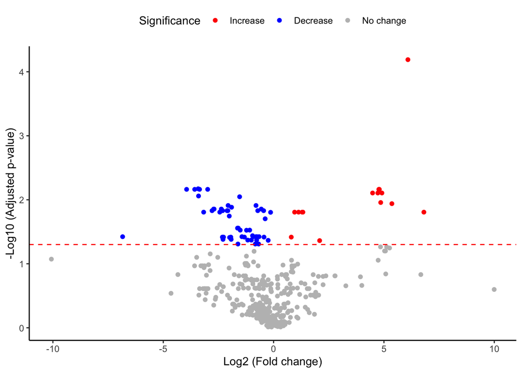

```r
#Volcano plot of differentially expressed substructures
lipid_species_substructure_result[[2]]
```

### 3-3. Pathway analysis results

In the ‘Pathway analysis’ section, the figure showcases the top 5 significant representative pathways within the network. Increased pathways are highlighted in red, while decreased pathways are shown in blue. A pathway is considered significant if its score exceeds 1.96. The figure represents pathways using starting and ending lipids. Additionally, a comprehensive summary of all significant pathways can be found in the accompanying table. For a deeper understanding of how we calculate pathway scores, calibrate pathways, and select representative pathways, detailed information is available in the iLipidome paper.

```r
#Pathway analysis result table
head(lipid_species_substructure_result[[3]])
```

```
##                                                                                                                                                    Pathway
## 1 LPA_22:6;0 --> PA_18:0;0_22:6;0 --> PI_18:0;0_22:6;0 --> DAG_18:0;0_22:6;0 --> PC_18:0;0_22:6;0 --> PS_18:0;0_22:6;0 --> PE_18:0;0_22:6;0 --> LPE_22:6;0
## 2 LPA_22:6;0 --> PA_18:0;0_22:6;0 --> PI_18:0;0_22:6;0 --> DAG_18:0;0_22:6;0 --> PE_18:0;0_22:6;0 --> PC_18:0;0_22:6;0 --> PS_18:0;0_22:6;0 --> LPS_22:6;0
## 3                LPA_22:6;0 --> PA_18:0;0_22:6;0 --> PI_18:0;0_22:6;0 --> DAG_18:0;0_22:6;0 --> PC_18:0;0_22:6;0 --> PS_18:0;0_22:6;0 --> PE_18:0;0_22:6;0
## 4                LPA_22:6;0 --> PA_18:0;0_22:6;0 --> PI_18:0;0_22:6;0 --> DAG_18:0;0_22:6;0 --> PE_18:0;0_22:6;0 --> PC_18:0;0_22:6;0 --> PS_18:0;0_22:6;0
## 5 LPA_18:0;0 --> PA_18:0;0_22:6;0 --> PI_18:0;0_22:6;0 --> DAG_18:0;0_22:6;0 --> PC_18:0;0_22:6;0 --> PS_18:0;0_22:6;0 --> PE_18:0;0_22:6;0 --> LPE_22:6;0
## 6 LPA_18:0;0 --> PA_18:0;0_22:6;0 --> PI_18:0;0_22:6;0 --> DAG_18:0;0_22:6;0 --> PE_18:0;0_22:6;0 --> PC_18:0;0_22:6;0 --> PS_18:0;0_22:6;0 --> LPS_22:6;0
##         From               To    Score   Type Representative pathway
## 1 LPA_22:6;0       LPE_22:6;0 6.548293 Active          18:0;0_22:6;0
## 2 LPA_22:6;0       LPS_22:6;0 6.451199 Active          18:0;0_22:6;0
## 3 LPA_22:6;0 PE_18:0;0_22:6;0 6.413633 Active          18:0;0_22:6;0
## 4 LPA_22:6;0 PS_18:0;0_22:6;0 6.413633 Active          18:0;0_22:6;0
## 5 LPA_18:0;0       LPE_22:6;0 6.399079 Active          18:0;0_22:6;0
## 6 LPA_18:0;0       LPS_22:6;0 6.301985 Active          18:0;0_22:6;0
```

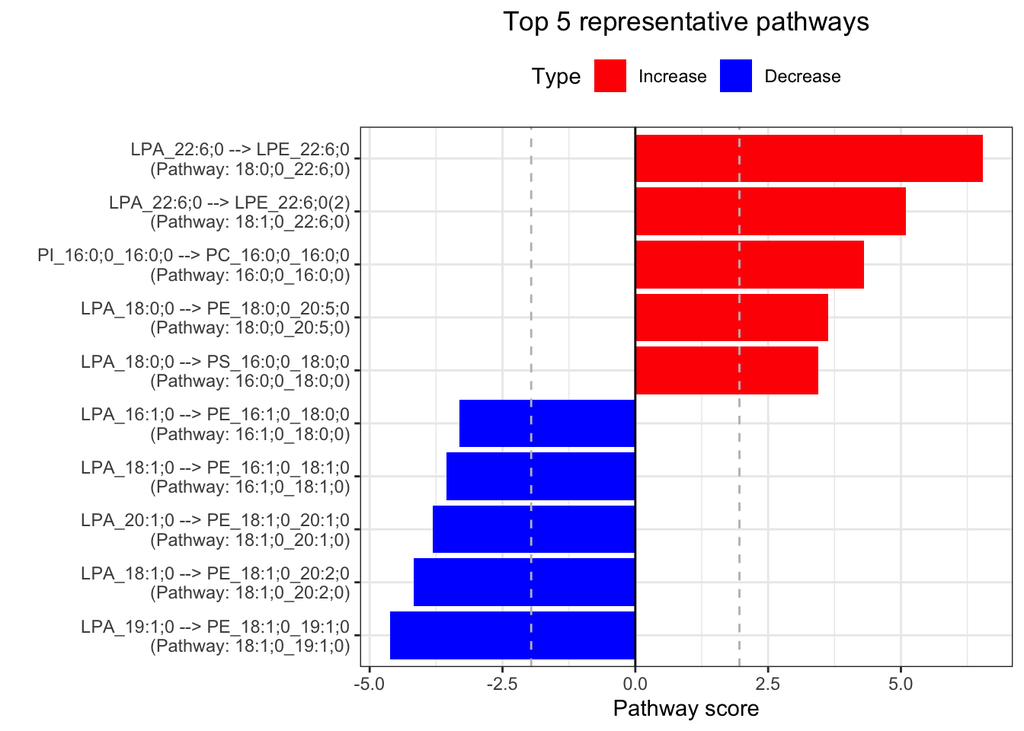

```r
#Top 5 significant representative pathways
lipid_species_substructure_result[[4]]
```

### 3-4. Reaction analysis results

In the ‘Reaction analysis’ section, the figure showcases the top 5 significant reactions within the network, where red and blue colors indicate an increase and decrease, respectively. A reaction is deemed significant if its p-value is below 0.05. These reactions are represented by substrate and product lipids, with red and blue text denoting the fold change of lipids. A comprehensive summary of all significant reactions is provided in the accompanying table. For a more detailed understanding of how we calculate reaction scores, please refer to the information in the iLipidome paper.

```r
#Reaction analysis result table
head(lipid_species_substructure_result[[5]])
```

```
##                          Reaction       P-value Perturbation score Significant
## 1 LPA_18:0;0 --> PA_18:0;0_22:6;0 0.00008925807          15.840287         yes
## 2              G3P --> LPA_22:6;0 0.00049005405          14.985890         yes
## 3 LPE_18:0;0 --> PE_18:0;0_22:6;0 0.00194975308          11.839700         yes
## 4 PS_17:1;0_18:0;0 --> LPS_18:0;0 0.00580518080          10.310413         yes
## 5 LPA_18:1;0 --> PA_18:1;0_22:6;0 0.00906010724          10.028842         yes
## 6 LPI_18:0;0 --> PI_18:0;0_22:6;0 0.00428542176           9.747989         yes
##       Type
## 1 Increase
## 2 Increase
## 3 Increase
## 4 Increase
## 5 Increase
## 6 Increase
##                                                                                                                                                                   Gene
## 1                                                                                  Abhd5, Agpat1, Agpat2, Agpat3, Agpat4, Agpat5, Gpat2, Gpat3, Lclat1, Mboat1, Mboat2
## 2                                                                                                                                            Gpam, Gpat2, Gpat3, Gpat4
## 3                                                                                                                                       Lpcat3, Lpcat4, Mboat1, Mboat2
## 4 Pla2g10, Pla2g12a, Pla2g12b, Pla2g1b, Pla2g2a, Pla2g2c, Pla2g2d, Pla2g2f, Pla2g3, Pla2g4a, Pla2g4b, Pla2g4c, Pla2g4d, Pla2g4e, Pla2g4f, Pla2g5, Pla2g6, Plaat3, Plb1
## 5                                                                                  Abhd5, Agpat1, Agpat2, Agpat3, Agpat4, Agpat5, Gpat2, Gpat3, Lclat1, Mboat1, Mboat2
## 6                                                                                                                                       Agpat3, Agpat4, Lclat1, Mboat7
```

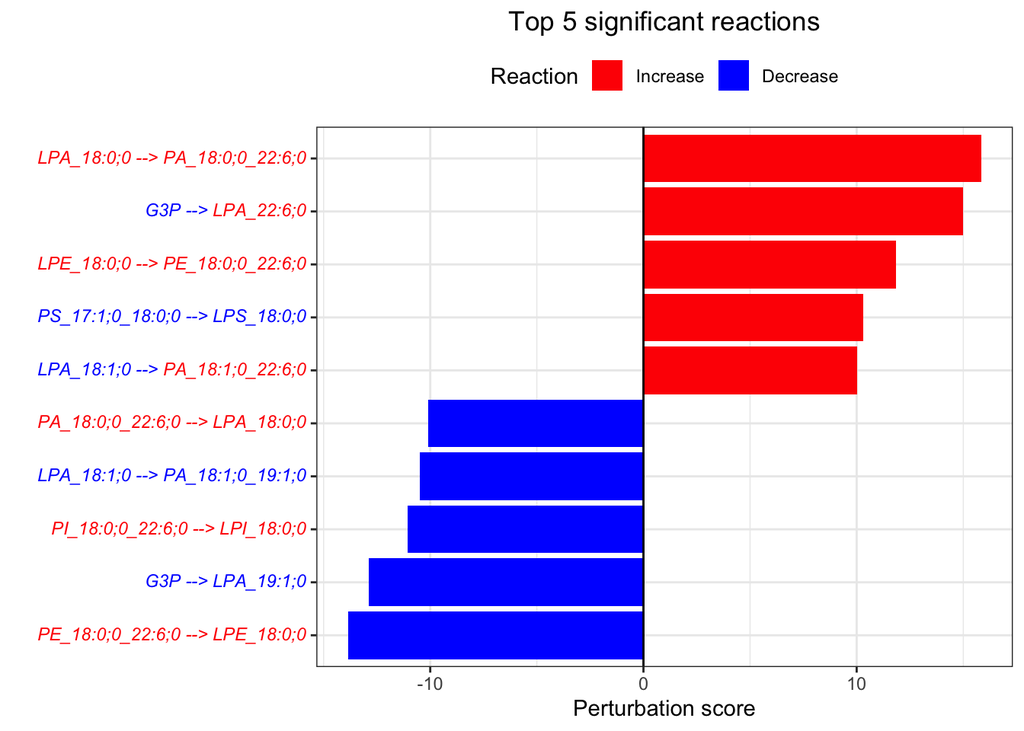

```r
#Top 5 significant reactions
lipid_species_substructure_result[[6]]
```

### 3-5. Lipid network

In the ‘Lipid network’ section, we constructed the Lipid Species Network and highlighted the top 5 significantly increased/decreased representative pathways and reactions. In the network visualization, red and blue colors indicate increase and decrease, respectively. The line width and color depth reflect the importance of pathways, while the text size represents the significance of reactions. Additionally, the nodes in the figure are filled based on the log2(fold change) values, and their sizes represent −log10(adjusted p-value). If a node exhibits significant changes in abundance, its border will be highlighted in purple. It’s important to note that for the Lipid Species Network, we only include the significant pathways that belong to the top 5 increased and decreased representative pathways to simplify the connections and enhance the clarity of the network visualization.

```r
#Node information for the network
head(lipid_species_substructure_result[[7]])
```

```
##                  id             label color.background color.border borderWidth
## 1  PA_16:1;0_18:0;0  PA_16:1;0_18:0;0          #EFEFFF       purple         2.5
## 2 DAG_16:1;0_18:0;0 DAG_16:1;0_18:0;0          #EFEFFF       purple         2.5
## 3  PA_16:0;0_16:0;0  PA_16:0;0_16:0;0          #C6C6FF        black         1.0
## 4 DAG_16:0;0_16:0;0 DAG_16:0;0_16:0;0          #FFDBDB       purple         2.5
## 5  PE_16:0;0_16:0;0  PE_16:0;0_16:0;0          #FFDBDB       purple         2.5
## 6        LPE_16:0;0        LPE_16:0;0          #FAFAFF        black         1.0
##        value font.size Mean(ctrl)   Mean(exp)        FC   Log2(FC)      P-value
## 1 1.82975901        35 1.45113863 1.079829600 0.7441257 -0.4263817 0.0009629795
## 2 1.70291705        35 1.34992112 1.032911521 0.7651644 -0.3861584 0.0019410415
## 3 0.26077650        35 0.01429084 0.004411343 0.3086833 -1.6958008 0.3986950877
## 4 1.80669087        35 1.23663662 2.634770866 2.1305942  1.0912559 0.0013978208
## 5 1.80669087        35 0.63728253 1.338064100 2.0996403  1.0701422 0.0013915432
## 6 0.08108683        35 0.03778778 0.033781734 0.8939856 -0.1616766 0.7655339685
##   Adjusted p-value Significance
## 1       0.01479929          yes
## 2       0.01981906          yes
## 3       0.54855920           no
## 4       0.01560663          yes
## 5       0.01560663          yes
## 6       0.82968486           no
```

```r
#Edge information for the network
head(lipid_species_substructure_result[[8]])
```

```
##               from               to color arrows length width    label
## 1       LPE_18:0;0 PE_18:0;0_22:6;0 black     to    100     1 Increase
## 2       LPI_18:0;0 PI_18:0;0_22:6;0 black     to    100     1 Increase
## 3       LPA_18:0;0 PA_18:0;0_22:6;0 black     to    100     1 Increase
## 4       LPA_18:1;0 PA_18:1;0_22:6;0 black     to    100     1 Increase
## 5              G3P       LPA_22:6;0 black     to    100     1 Increase
## 6 PA_18:0;0_22:6;0       LPA_18:0;0 black     to    100     1 Decrease
##   font.size font.color                        Reaction       P-value
## 1      35.0        red LPE_18:0;0 --> PE_18:0;0_22:6;0 0.00194975308
## 2      20.0        red LPI_18:0;0 --> PI_18:0;0_22:6;0 0.00428542176
## 3      50.0        red LPA_18:0;0 --> PA_18:0;0_22:6;0 0.00008925807
## 4      27.5        red LPA_18:1;0 --> PA_18:1;0_22:6;0 0.00906010724
## 5      42.5        red              G3P --> LPA_22:6;0 0.00049005405
## 6      20.0       blue PA_18:0;0_22:6;0 --> LPA_18:0;0 0.00560777872
##   Perturbation score     Type
## 1          11.839700 Increase
## 2           9.747989 Increase
## 3          15.840287 Increase
## 4          10.028842 Increase
## 5          14.985890 Increase
## 6         -10.078315 Decrease
##                                                                                                                                                                   Gene
## 1                                                                                                                                       Lpcat3, Lpcat4, Mboat1, Mboat2
## 2                                                                                                                                       Agpat3, Agpat4, Lclat1, Mboat7
## 3                                                                                  Abhd5, Agpat1, Agpat2, Agpat3, Agpat4, Agpat5, Gpat2, Gpat3, Lclat1, Mboat1, Mboat2
## 4                                                                                  Abhd5, Agpat1, Agpat2, Agpat3, Agpat4, Agpat5, Gpat2, Gpat3, Lclat1, Mboat1, Mboat2
## 5                                                                                                                                            Gpam, Gpat2, Gpat3, Gpat4
## 6 Pla2g10, Pla2g12a, Pla2g12b, Pla2g1b, Pla2g2a, Pla2g2c, Pla2g2d, Pla2g2f, Pla2g3, Pla2g4a, Pla2g4b, Pla2g4c, Pla2g4d, Pla2g4e, Pla2g4f, Pla2g5, Pla2g6, Plaat3, Plb1
```

```r
#Lipid network
lipid_species_substructure_result[[9]]
```

[interactive chart not shown]